# Exploring 2017 FHFA Mortgage Loan Data by Alex Craver

> **About the Data**: This dataset has been provided by the Federal Housing Finance Agency (FHFA). The data has been collected by Fannie Mae and Freddie Mac and is regulated by the FHFA. The data provided shows statistics about individuals and mortgages in the year 2017.

> **Variables Used**:We will look at the follow variables in this exploration:
1. Bank: Name of Federal Home Loan Bank District
2. FIPSStateCode: FIPS State Code (or number that represents a state)
3. Income: Total borrower income in whole dollar
4. IncRate: Borrower income ratio
5. LTV: Loan to value ration at origination
6. Purpose: Loan purchase; purchasing, refinancing, second mortgage, new construction, or rehabilitation.
7. Product: Product type; fixed rate, ARM, baloon, GPM, Reverse Annuity, other
8. FedGuar: Federal guarantee
9. First: First time homebuyer
10. BoRace: Borrower’s race
11. BoGender: Borrower’s gender
12. BoAge: Borrower’s age
13. Rate: Interest rate
14. Amount: Loan amount in whole dollars
15. BoCreditScor: Borrower’s credit score

# Univariate Plots Section

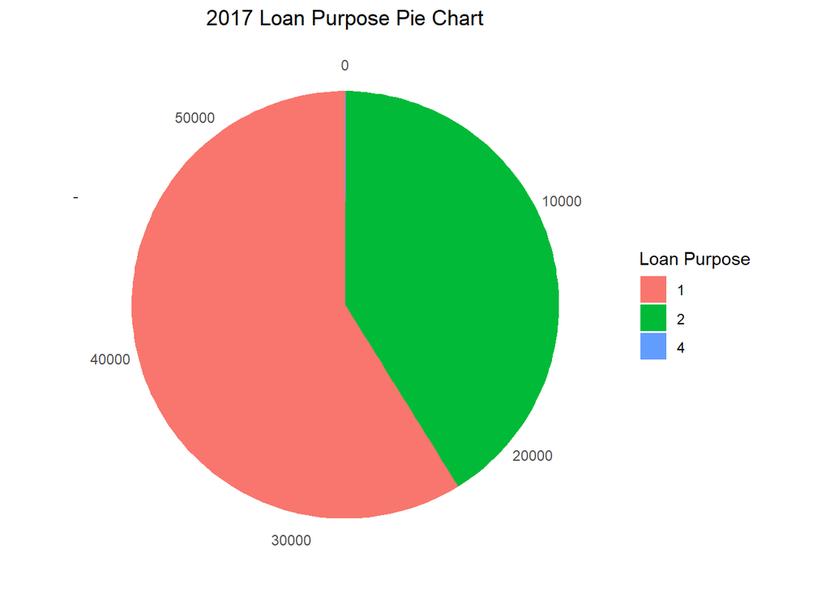

**In 2017, what were the purposes for most of the loans?**

Looking at this pie chart, the Loan Purpose color is represented by numbers 1-4. 1=purchase, 2= refinancing, 3=second mortgage, 4=new construction. The majority of mortgages were being taken out for purchases and then refinancing.

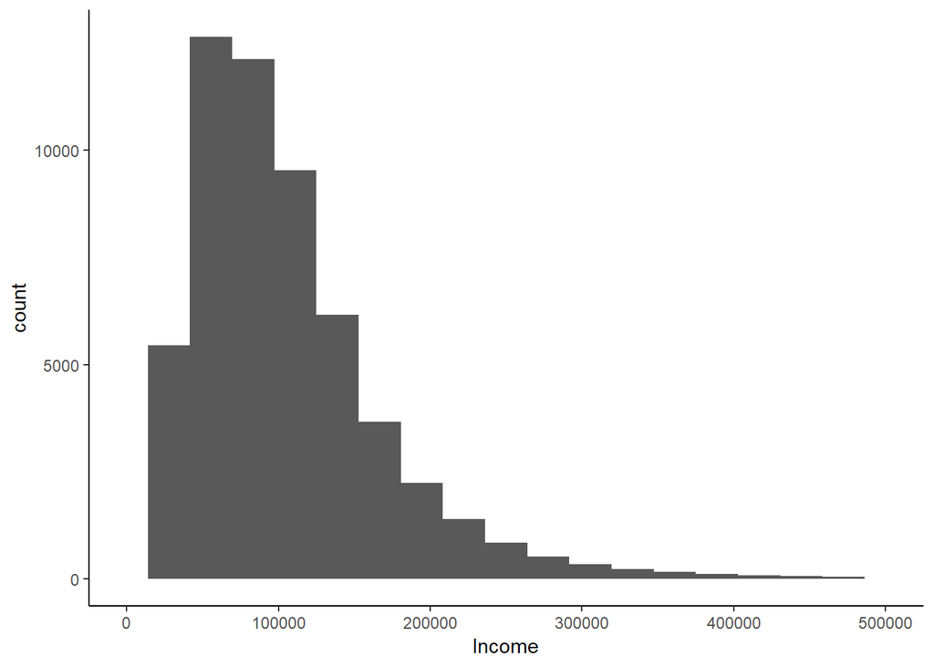

```
##    Min. 1st Qu.  Median    Mean 3rd Qu.    Max.
##    3396   60408   91520  109301  133896 4205372
```

**What is the average income that a person has who is taking out a loan?**

The majority of those that were taking out a mortgage ran between an average annual income of $30,000-$100,000. After that, income starts to go down with only af ew outliers making $500,000 or more per year.

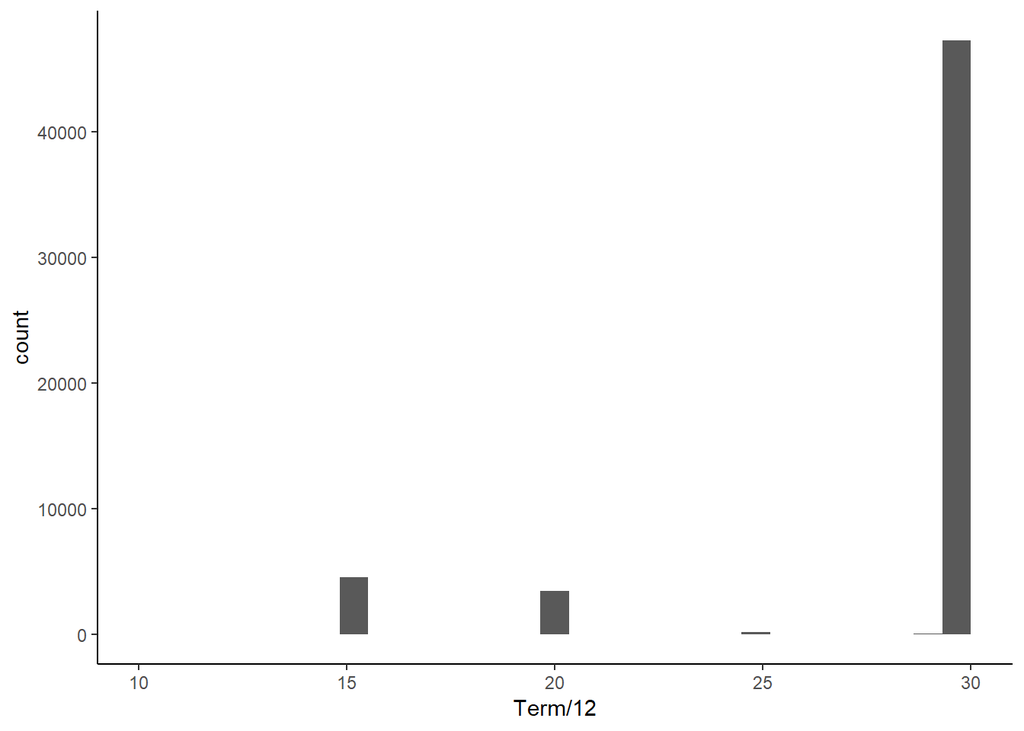

**In years, what is the duration of most loans?**

As expected, the majority of borrowers are taking out 30 year loans. It was interesting to note that there is a significant portion of borrowers taking out 20 year loans as well. Contrary to the typical 30 or 15 year loan.

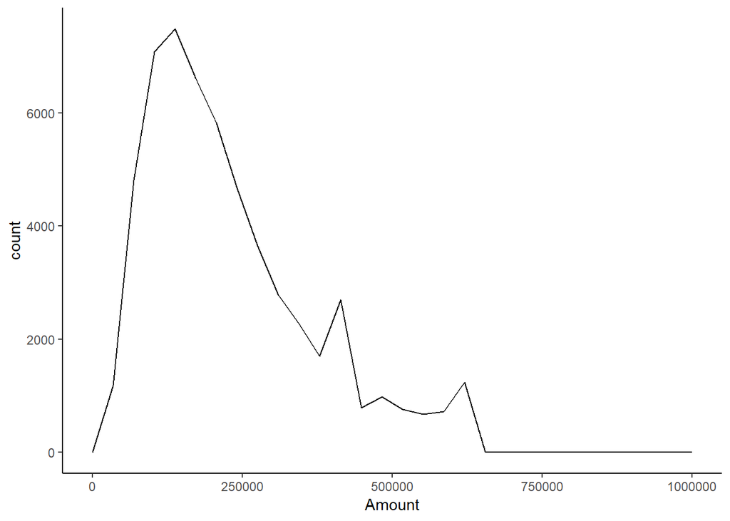

```
##    Min. 1st Qu.  Median    Mean 3rd Qu.    Max.
##   12000  125000  194400  230053  300000 1223475
```

**What is the most common amount individuals are taking out for mortgages?**

The majority of customers shopping for mortgages are taking out $250,000 and less. The median amount is $194,000, and the mean or average is about $230,053.

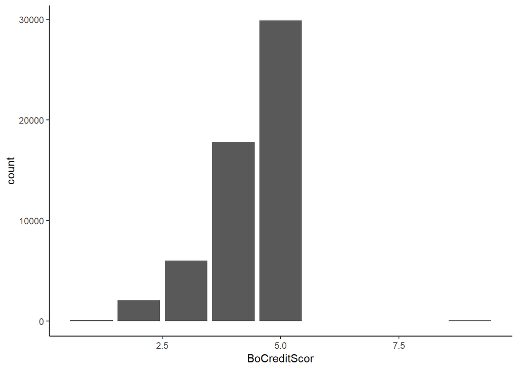

```
##    Min. 1st Qu.  Median    Mean 3rd Qu.    Max.
##   1.000   4.000   5.000   4.354   5.000   9.000
```

**What is the average borrowers credit score?**

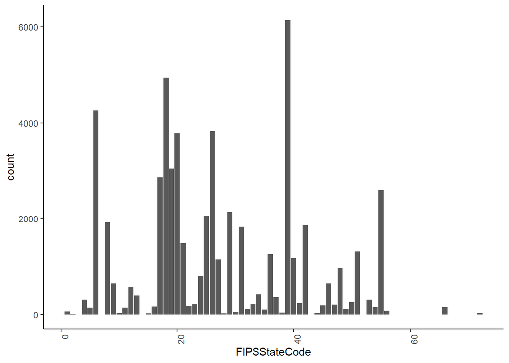

```
##
##    1    2    4    5    6    8    9   10   11   12   13   15   16   17   18
##   63    6  304  140 4260 1924  649   28  142  569  391   17  164 2860 4938
##   19   20   21   22   23   24   25   26   27   28   29   30   31   32   33
## 3044 3787 1490  181  207  808 2060 3831 1151   20 2139   46 1825  113  206
##   34   35   36   37   38   39   40   41   42   44   45   46   47   48   49
##  413  100 1260  357   32 6143 1182  235 1859   28  183  655  204  978  117
##   50   51   53   54   55   56   66   72
##  254 1314  303  151 2600   74  156   29
```

**Which state saw the greatest amounts of loans in 2017?**

```
## [1] 6143
```

State code 39, or the state of Ohio, saw 6,143 individuals with mortgages.

# Univariate Analysis

### What is the structure of your dataset?

```
## 'data.frame':    55990 obs. of  19 variables:
##  $ Bank         : Factor w/ 11 levels "Atlanta","Boston",..: 1 1 1 1 1 1 1 1 1 1 ...
##  $ FIPSStateCode: int  72 66 66 48 6 39 35 24 42 17 ...
##  $ LocMedY      : int  17448 51900 51900 70673 55611 60528 63943 87788 81157 70718 ...
##  $ Income       : int  60588 210264 114744 164988 56160 115764 94548 221592 113568 68004 ...
##  $ IncRat       : num  3.29 4.05 2.21 2.34 1.05 ...
##  $ LTV          : num  0.89 0.94 1.04 0.75 0.85 0.98 1 0.96 1 1 ...
##  $ Purpose      : int  2 2 1 2 2 2 2 2 2 1 ...
##  $ Product      : int  1 1 1 1 1 1 1 1 1 1 ...
##  $ FedGuar      : int  2 2 2 2 2 2 2 2 2 2 ...
##  $ Term         : int  180 360 360 360 360 360 360 360 360 360 ...
##  $ First        : int  2 2 2 2 2 2 2 2 2 2 ...
##  $ BoRace       : int  7 5 7 3 5 5 5 5 5 5 ...
##  $ BoGender     : int  1 1 1 1 1 1 1 1 1 2 ...
##  $ CoGender     : int  2 2 2 2 2 4 2 4 2 4 ...
##  $ BoAge        : int  70 60 36 55 48 55 68 52 41 45 ...
##  $ Rate         : num  0.0288 0.0325 0.0325 0.0338 0.0325 0.0325 0.0325 0.0338 0.0325 0.0325 ...
##  $ Amount       : int  75000 520000 429831 251800 290613 103000 190000 381000 233000 257648 ...
##  $ BoCreditScor : int  5 5 5 4 3 3 4 4 4 5 ...
##  $ PropType     : Factor w/ 9 levels "PT01","PT02",..: 1 1 1 5 1 1 1 1 5 5 ...
## NULL
```

55990 rows and 19 columns.

### What is/are the main feature(s) of interest in your dataset?

The main features of interest in the dataset are: Income, Amount, Term, Borrowers Credit Score, and Rate.

### What other features in the dataset do you think will help support your investigation into your feature(s) of interest?

Other features that may be of interst include, Loan to Value, Race, Gender, State, PropType, Purpose, BoAge.

### Did you create any new variables from existing variables in the dataset?

N/A

### Of the features you investigated, were there any unusual distributions? Did you perform any operations on the data to tidy, adjust, or change the form of the data? If so, why did you do this?

The dataset from FHFP was quite clean. The structure was properly laid out in it’s CSV form so there was no significant changes to be made.

# Bivariate Plots Section

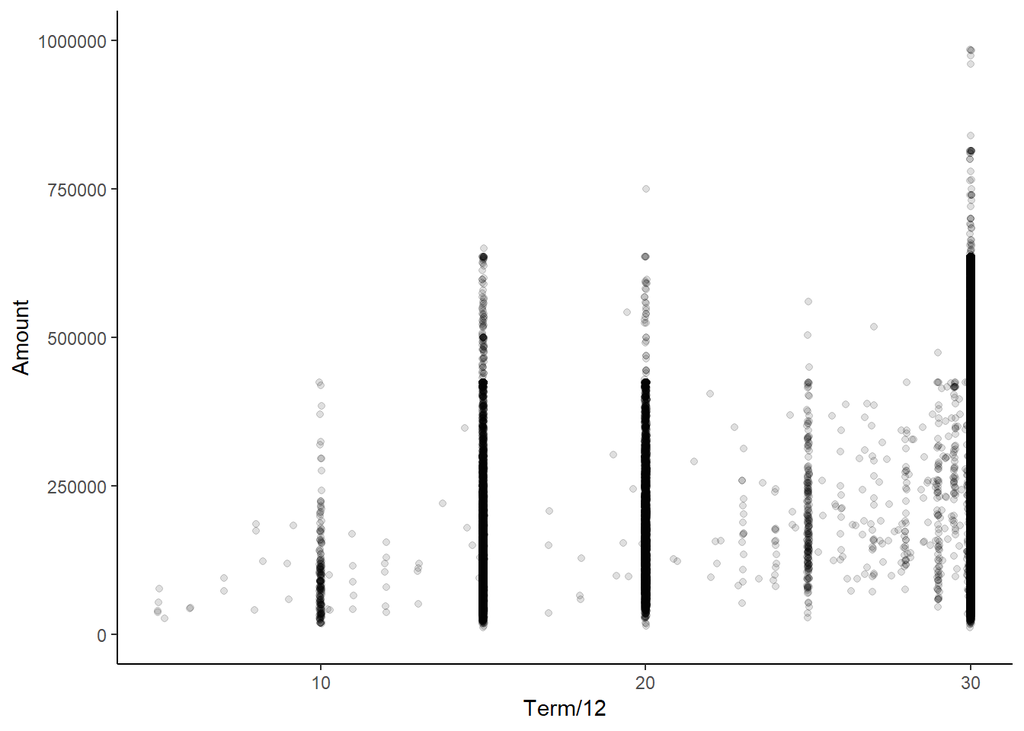

```
## [1] 0.1982247
```

**With increasing loan terms, does the amount of the loan increase?**

Looking at the correlation coefficient between Term and Amount of .19, it reveals there is not a significant relation between how long of a term and the amount of the loan. One would assume that with a larger term a borrower would take out a larger sum of money. Is this by choice of the bank or individual?

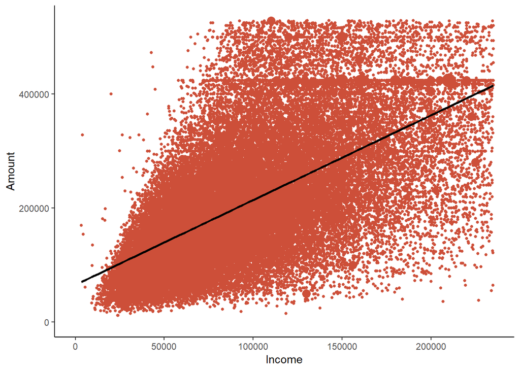

```
## [1] 0.4788115
```

**Does income affect loan amount?**

With a correlation coefficient of .478, there does seem to be a larger relation than the previous observation of term to amount. If one has a larger income, it seems as if the borrower has a greater chance of taking out a larger mortage.

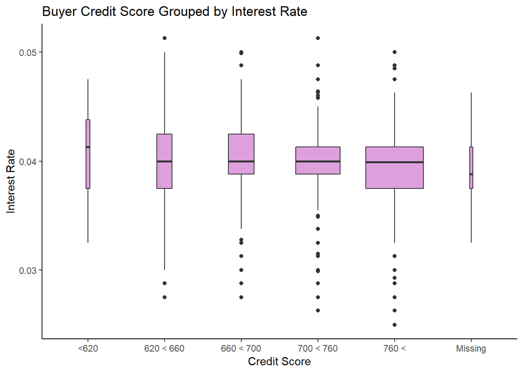

**Does credit score affect interest rate?**

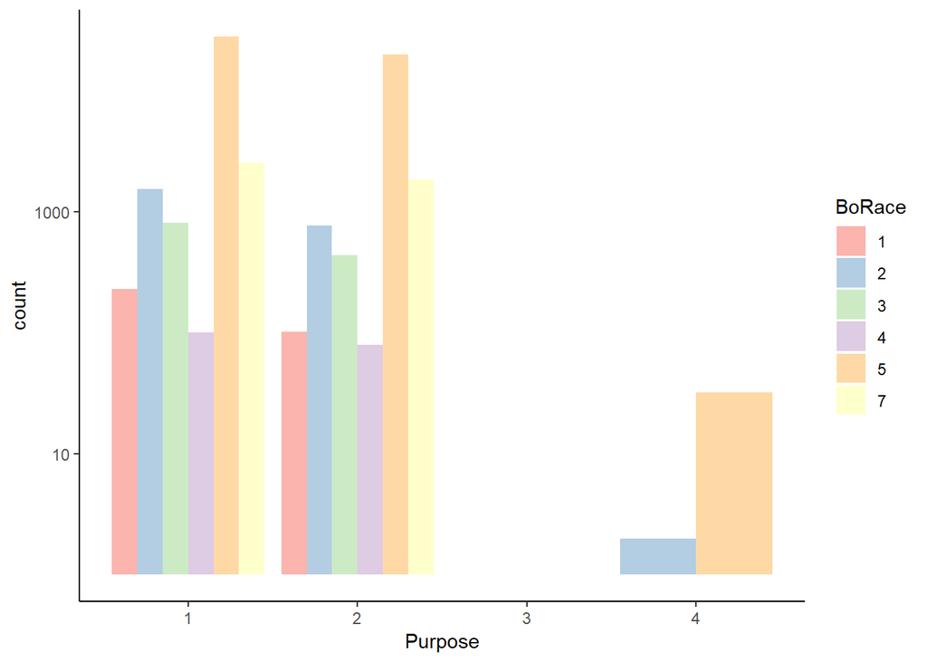

**What race is taking out the most mortgages and for what purpose?**

Across all loan purposes (1: Purchase, 2: Refinancing, 3: Second Mortgage, 4: New Construction, 5: Rehab), it appears that white borrowers are borrrowing the most, followed by Asian borrowers, then black borrowers.

For borrower race: 1: American Indian or Alaska Native, 2: Asian, 3: Black or African American, 4: Native Hawaiian, 5: White, 6: Information not provided

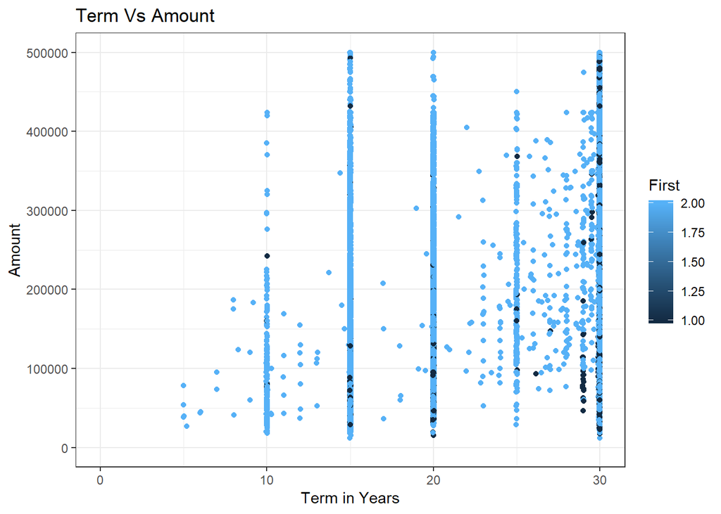

**What is the duration of loans and amount in relation to first time home buyers or not?**

First time home buyers are represented by 1. It appears that the majority of first time homebuyers are taking out close to 30 year loans and generally under $300,000.

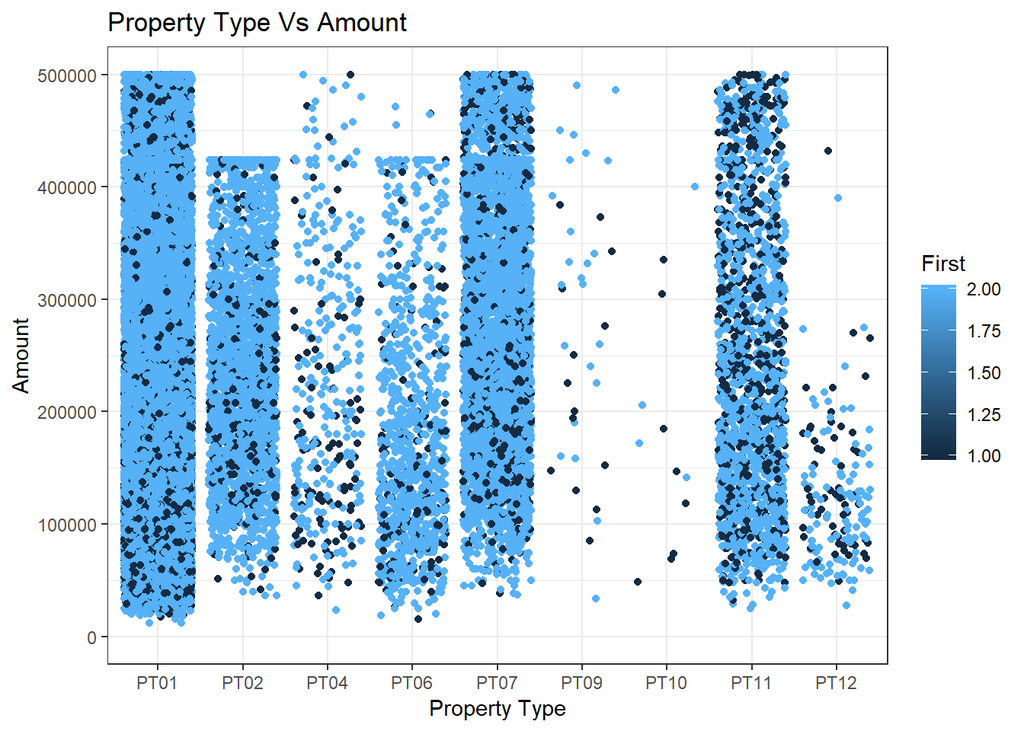

**What is the relation between between Property type (PT01-Single Family detached, PT02-Deminums PUD, PT03-Single Family Attached, PT04-Two Family, PT05-Townhouse, PT06-Low-Rise Condo, PT07-PUD, PT08-Duplex, PT09-Three Family, PT10-Four Family, PT11-Hi Rise Condo, PT12-Manufactured Home) and amount of loan? What kind of homes are first-time home buyers buying vs non-first time home buyers?**

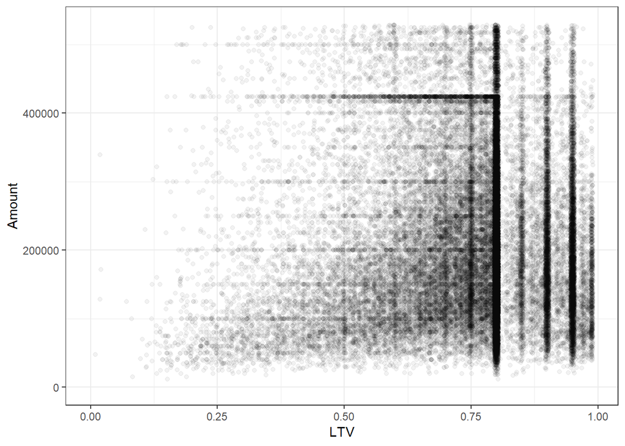

```
## [1] -0.03777583
```

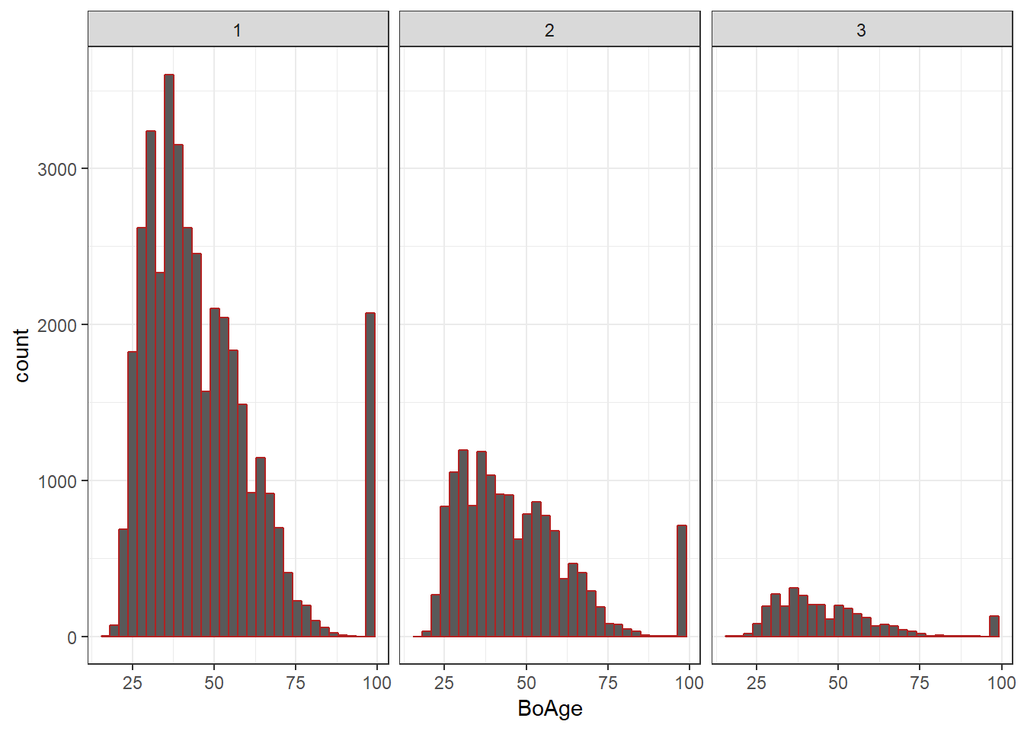

**What is the count of borrower’s age in relation to gender?**

# Bivariate Analysis

### Talk about some of the relationships you observed in this part of the investigation. How did the feature(s) of interest vary with other features in the dataset?

The most simple observation from the bivariate analysis was the relation of income to amount borrowed. It was the easiest to see that with larger income comes larger amount borrowed. However, there are several other variables that broke down some insight between amount borrowed. Credit scores seem to be important to interest rates; the better the score, the better the chance of having an interest rate around 3-4%.

### What was the strongest relationship you found?

The strongest relationship found was between income and amount borrowed.

# Multivariate Plots Section

[figure not shown]

```
## [1] 0.17195
```

**What is the relation between term and amount?**

There did not seem to be a significant replationship between loan term and amount taken out. This plot also showed first time home buyers and borrower income ratios. Encircled are those that have taken out shorter loan periods and borrowed over $400,000.

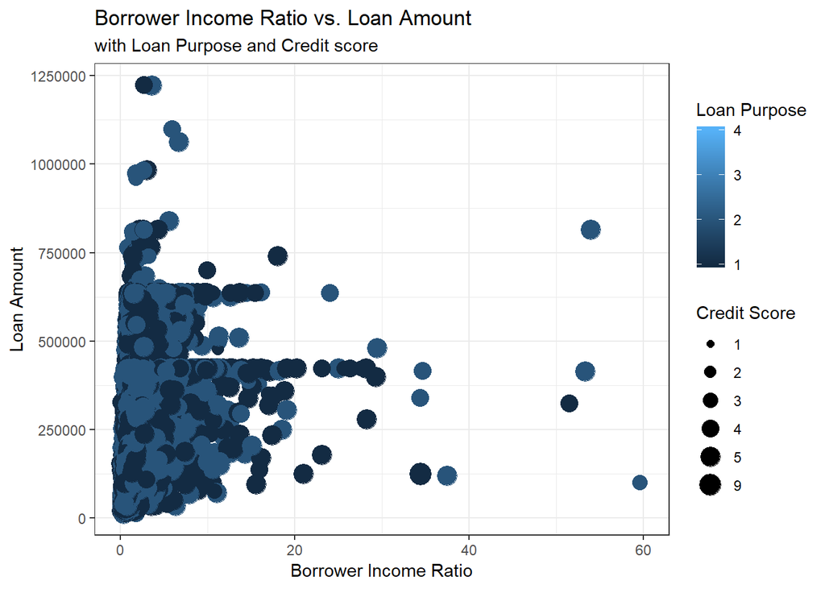

```
## [1] 0.3497711
```

**What is the relationship of borrower income ratio to loan amount?** For the most part, it seems as if lenders prefer borrower income rations to be under 20%. There also seems to be a preference for higher credit scores and the majority of the purchases are for home purchases. With a correlation coefficient of about 35%, there is a small relationship between borrower income ration to loan amount.

# Multivariate Analysis

### Talk about some of the relationships you observed in this part of the investigation. Were there features that strengthened each other in terms of looking at your feature(s) of interest?

# Final Plots and Summary

### Plot One

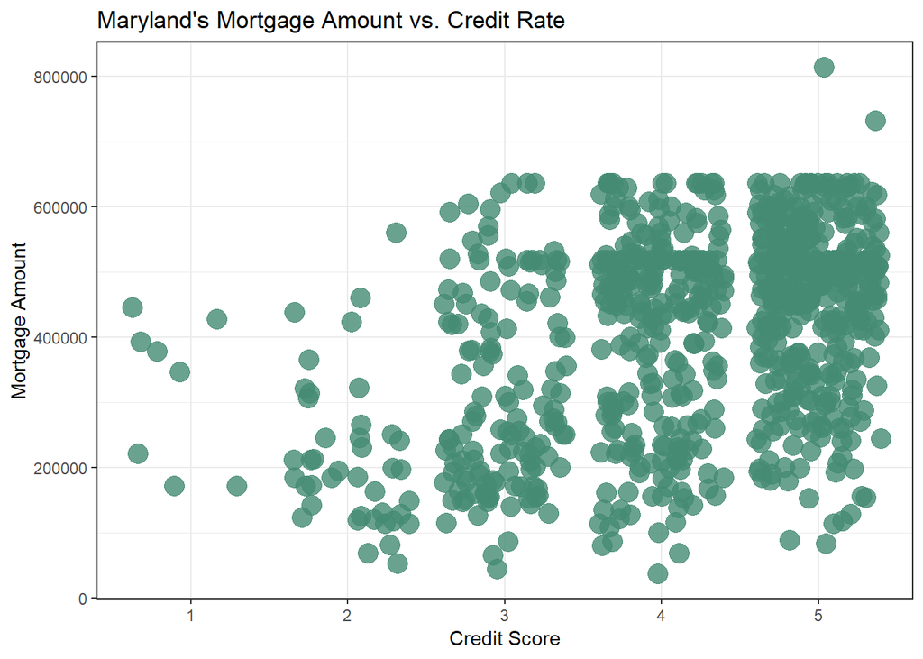

### Description One

For the final project, I decided to narrow down the data to a state level and selected my home state of Maryland. This plot looks at the credit score of borrowers from Maryland vs. Mortgage amounts. The x-axis is BoCredScor, which is the borrowers credit score. The y axis is the amount, or amount of the borrower’s mortgage.

From the graph, it is clear that the lenders preferred credit score is between the 4 and 5 tick, so from a credit score of 700 and greater. Additionally, mortgages are being taken out for a large amount with the majority between $400,000-$600,000.

### Plot Two

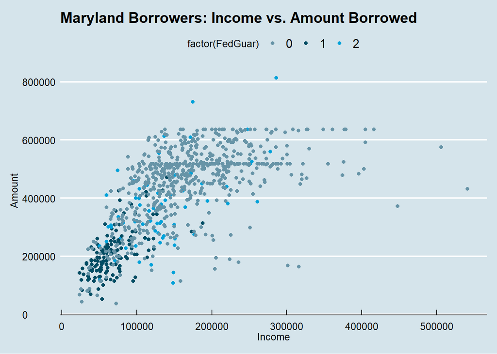

### Description Two

This plot looks at the relation between Maryland borrowers income and amount and colored if the loan has a federal guarantee. The x axis is the borrowers income, and the y axis is the amount of the mortgage. The points are colored by federal guarantee. The federal guarantees are 0: no federal guarantee, 1: FHA, 2: VA, 3: FMHA, 4:HECMS.

As a result of the plot, it looks like a positive relationship between income and amount.The majority of loans look like they have no federal guarantee, but there are several loans taken out as FHA loans.

### Plot Three

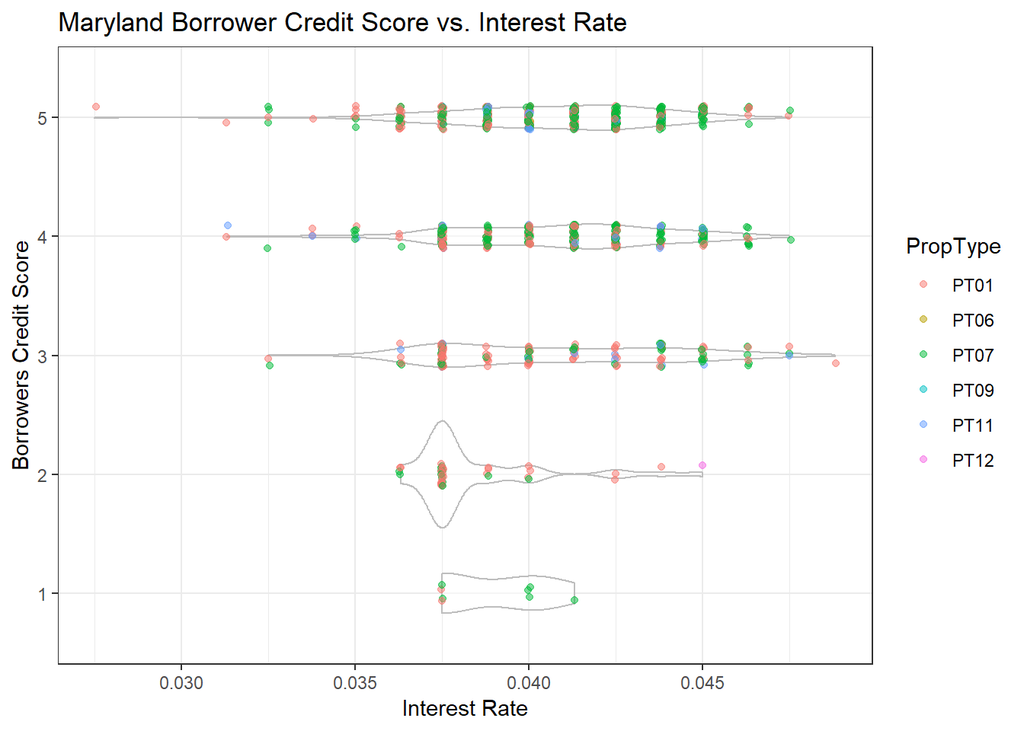

### Description Three

This third graph looks at borrowers in Maryland and their credit score vs their interest rate. A better credit score will be 4 or 5. A better interest rate will be closer to zero.

# Reflection

The mortgage loan dataset represents close to 56,000 loans across 19 variables from 2017. The source website had a great listing of data definitions, so I started by printing out the definitions and circling which ones I thought would be most useful for my analysis.

I started with a few datasets, one on gun data, jail data, and another bank loan dataset provided by Udacity, but found this one more interesting after having just gone through the mortgage process most recently myself. It gave me insight on how a lender goes about approving lenders, and what kind of risks are involved when distributing loans. The analysis supports finding a borrower that is financially responsible and has a generally safe background in terms of credit usage, income, and borrower income ratio.

Some challenges I faced were getting graphs to show up. There were a few instances I could not get categorical variables to display, but after some Google research, I was able to figure out that most of the dataset was numberical, and several variables had to be adjusted to factors. I also had trouble with some of the visualizations so I referenced several helpful websites that gave examples of better looking plots.

A question I would pose if I was to do this again would be how does this dataset in the year 2017 compare to that say of 2008 when there was a housing crash? Or even the year after? Did interest rates shoot up? Did the amount of borrowers decline? A more detailed analysis looking at multiple years could be beneficial for trends and changes over time.

> **Resources**: http://r-statistics.co/Top50-Ggplot2-Visualizations-MasterList-R-Code.html https://stackoverflow.com/questions/20529252/changing-x-axis-tick-labels-in-r-using-ggplot2 https://www.r-bloggers.com/r-using-rcolorbrewer-to-colour-your-figures-in-r/ https://www.youtube.com/watch?v=WpMT4RvPzx8 https://www.fhfa.gov/DataTools/Downloads/Pages/Public-Use-Databases.aspx https://stackoverflow.com/questions/1330989/rotating-and-spacing-axis-labels-in-ggplot2 https://www.sharpsightlabs.com/blog/data-analysis-example-r-supercars-part2/ http://zevross.com/blog/2014/08/04/beautiful-plotting-in-r-a-ggplot2-cheatsheet-3/ https://www.statmethods.net/input/contents.html https://rmarkdown.rstudio.com/authoring_basics.html